# tarea_dataset

# SERIE TEMPORAL

## Se grafico el numero de homicidios reportados por cada mes del año 2023, la mayor cantidad de homicidios se presento en marzo, abril, julio y octubre. los valores mas bajos fueron en junio y septiembre

```r
data_set$`FECHA HECHO` <- as.POSIXct(data_set$`FECHA HECHO`, format = "%m/%d/%Y %I:%M:%S %p")
data_set
```

| ARMA MEDIO | DEPARTAMENTO | MUNICIPIO | FECHA HECHO | GENERO | *AGRUPA_EDAD_PERSONA | CODIGO DANE | CANTIDAD |
| --- | --- | --- | --- | --- | --- | --- | --- |
| MOTO | VALLE | Andalucía | 2023-04-09 | MASCULINO | ADULTOS | 76036000 | 1 |
| MOTO | VALLE | Andalucía | 2023-04-17 | FEMENINO | ADULTOS | 76036000 | 1 |
| MOTO | VALLE | Bolívar | 2023-02-26 | MASCULINO | ADOLESCENTES | 76100000 | 1 |
| MOTO | VALLE | Buenaventura | 2023-01-03 | MASCULINO | ADULTOS | 76109000 | 1 |
| MOTO | VALLE | Bugalagrande | 2023-07-20 | MASCULINO | ADULTOS | 76113000 | 1 |
| MOTO | VALLE | Cali (CT) | 2023-01-01 | MASCULINO | ADULTOS | 76001000 | 1 |
| MOTO | VALLE | Cali (CT) | 2023-01-04 | MASCULINO | ADULTOS | 76001000 | 1 |
| MOTO | VALLE | Cali (CT) | 2023-01-06 | MASCULINO | ADULTOS | 76001000 | 1 |
| MOTO | VALLE | Cali (CT) | 2023-01-12 | MASCULINO | ADULTOS | 76001000 | 1 |
| MOTO | VALLE | Cali (CT) | 2023-01-23 | MASCULINO | ADULTOS | 76001000 | 1 |

[output cut: 389 more lines]

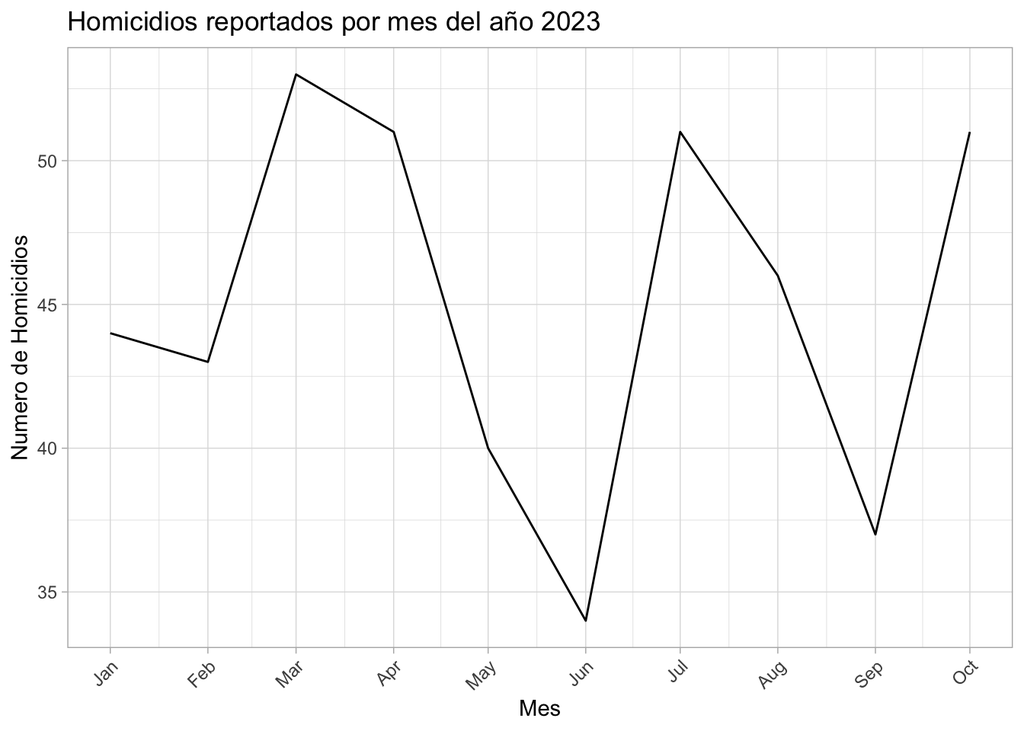

```r
serie_temporal <- data_set%>%
  select(`FECHA HECHO`, CANTIDAD)%>%
  group_by(Mes=floor_date(`FECHA HECHO`, "month")) %>%
  summarise( `Numero de Homicidios`= sum(CANTIDAD))%>%
  ggplot(aes(x = Mes, y = `Numero de Homicidios`))+
  theme_light()+
  geom_line()+
  labs(title = "Homicidios reportados por mes del año 2023")+
  scale_x_datetime(date_breaks = "1 month", date_labels = "%b") +
  theme(axis.text.x = element_text(angle = 45, hjust = 1))
serie_temporal
```

# Boxplor ## Se realizó un resumen estadistico de los 5 primeros municipios del dataframe.Promedio punto azul, naranja punto minimo, max punto amarillo, madiana punto negro, primer cuartil punto rojo, tercer cuartil punto verde.

```r
caja <- data_set%>%
   select(MUNICIPIO, CANTIDAD)%>%
   group_by(MUNICIPIO)%>%
   summarise(suma=sum(CANTIDAD))
caja
```

| MUNICIPIO | suma |
| --- | --- |
| Alcalá | 4 |
| Andalucía | 11 |
| Ansermanuevo | 2 |
| Bolívar | 2 |
| Buenaventura | 10 |
| Bugalagrande | 4 |
| Caicedonia | 2 |
| Cali (CT) | 144 |
| Calima | 7 |
| Candelaria | 22 |

[output cut: 26 more lines]

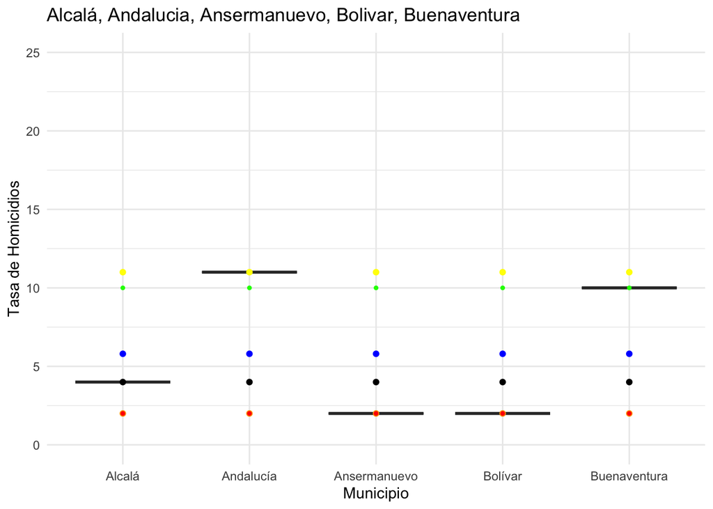

```r
cinco_valores <- head(caja, 5)

# Graficar el boxplot con los cinco primeros valores
ggplot(cinco_valores, aes(x = MUNICIPIO, y = suma)) +
  geom_boxplot(fill = "gray", outlier.shape = NA) +
  geom_point(aes(y = mean(suma)), col = 'blue', shape = 19) +
  geom_point(aes(y = min(suma)), col = 'orange', shape = 19) +
  geom_point(aes(y = max(suma)), col = 'yellow', shape = 19) +
  geom_point(aes(y = median(suma)), col = 'black', shape = 19) +
  geom_point(aes(y = quantile(suma, probs = 0.25)), col = 'red', shape = 20) +
  geom_point(aes(y = quantile(suma, probs = 0.75)), col = 'green', shape = 20) +
  labs(
    x = "Municipio",
    y = "Tasa de Homicidios",
    title = "Alcalá, Andalucia, Ansermanuevo, Bolivar, Buenaventura"
  ) +
  ylim(0, 25) +
  scale_fill_manual(values = c('gray')) +
  scale_shape_manual(values = c(19, 19, 19, 19, 20, 20)) +
  scale_color_manual(values = c('blue', 'orange', 'yellow', 'black', 'red', 'green')) +
  theme_minimal() +
  theme(legend.position = "bottomright") +
  guides(fill = guide_legend(title = "Estadísticas"))
```